# Scitsitats Code File

Applying data visualisation methods, we find that:

- age

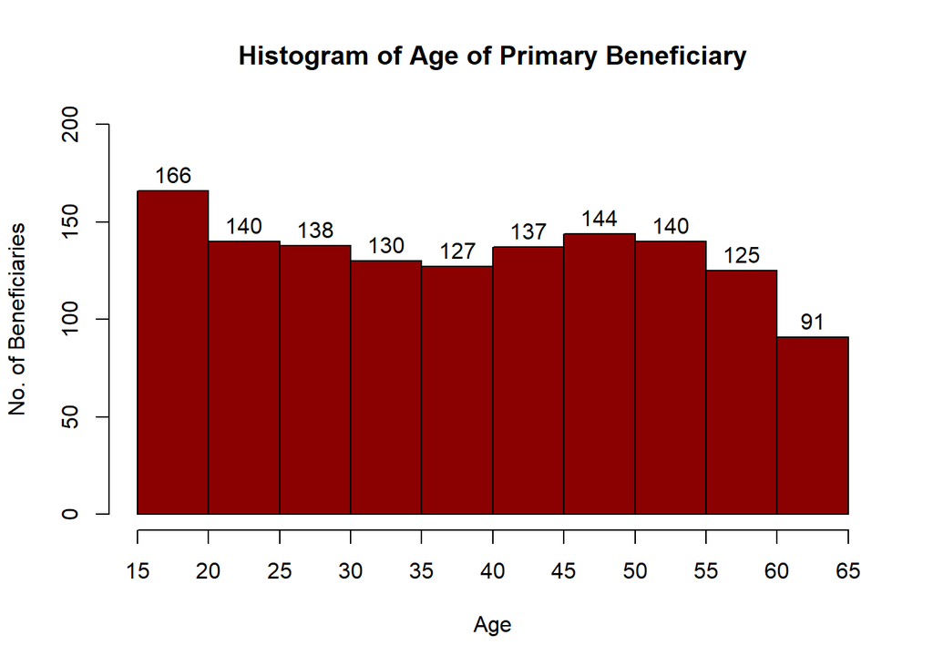

```r
h.age <- hist(df$age,
            main = "Histogram of Age of Primary Beneficiary",
            labels = TRUE,
            xlab = "Age",
            ylab = "No. of Beneficiaries",
            col = "darkred",
            xlim = c(15, 65),
            ylim = c(0, 200),
            xaxp = c(15, 65, 10))
```

```r
age.group <- cut(df$age, breaks = h.age$breaks, include.lowest = TRUE, dig.lab = 5)
age_freq <- table(age.group)
kable(age_freq, caption = "Frequency Distribution by Age of Primary Beneficiary")
```

Frequency Distribution by Age of Primary Beneficiary

| age.group | Freq |
| --- | --- |
| [15,20] | 166 |
| (20,25] | 140 |
| (25,30] | 138 |
| (30,35] | 130 |
| (35,40] | 127 |
| (40,45] | 137 |
| (45,50] | 144 |
| (50,55] | 140 |
| (55,60] | 125 |
| (60,65] | 91 |

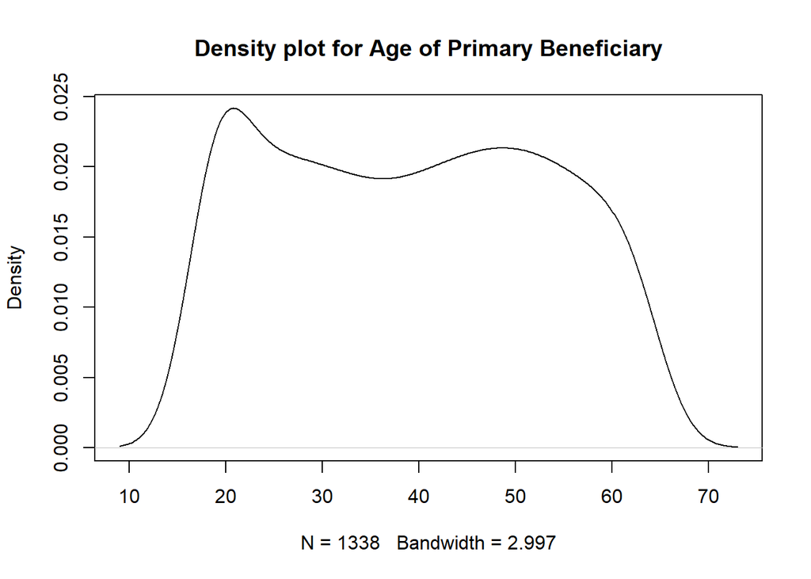

```r
plot(density(df$age), main="Density plot for Age of Primary Beneficiary")
```

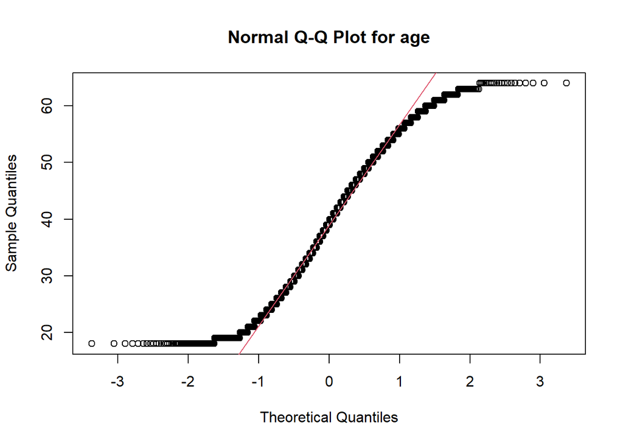

```r
qqnorm(df$age,
       main="Normal Q-Q Plot for age")
qqline(df$age, col=2)
```

From the histogram, we see that the frequency distribution of primary beneficiaries across ages is relatively balanced between the ages of 20 and 60. We see that the extreme low values are higher whereas the extreme high values of age are considerably lower (the number of beneficiaries aged between 60 and 65 is almost half of the number of beneficiaries who are aged between 15 and 20). This is similarly highlighted in the density plot where we see that there are fewer extreme points as compared to a normal distribution curve. Using the value of excess kurtosis at -1.25, we find that the distribution of age is platykurtic with a ligher tail (i.e. fewer extreme points).

- sex

```r
sexFreq <- df %>%
  count(sex)

kable(sexFreq, caption = "Frequency of Beneficiaries by Gender")
```

Frequency of Beneficiaries by Gender

| sex | n |
| --- | --- |
| female | 662 |
| male | 676 |

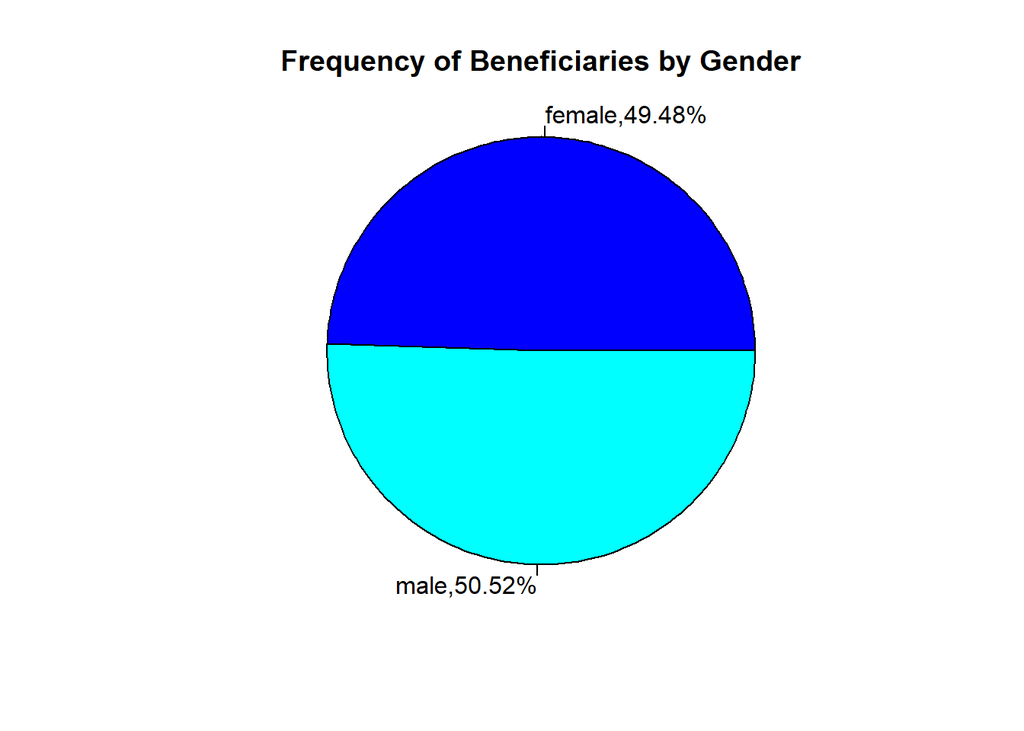

```r
slice.sex <- sexFreq$n
sex.piepercent <- 100 * round(sexFreq$n / sum(sexFreq$n), 4)
label <- paste(sexFreq$sex, ",", sep = "", sex.piepercent, "%")
pie(slice.sex,
    labels = label,
    col = c("blue", "cyan"),
    radius = 1,
    main = "Frequency of Beneficiaries by Gender")
```

From the pie chart, we see that there is a balance across genders. The percentage of female insurance beneficiaries is approximately equal to the percentage of male insurance beneficiaries, with there being 1.04% of primary insurance beneficiaries being male as compared to those who are female. We can hence infer that the gender of beneficiaries has little impact on their probability of buying insurance.

- bmi

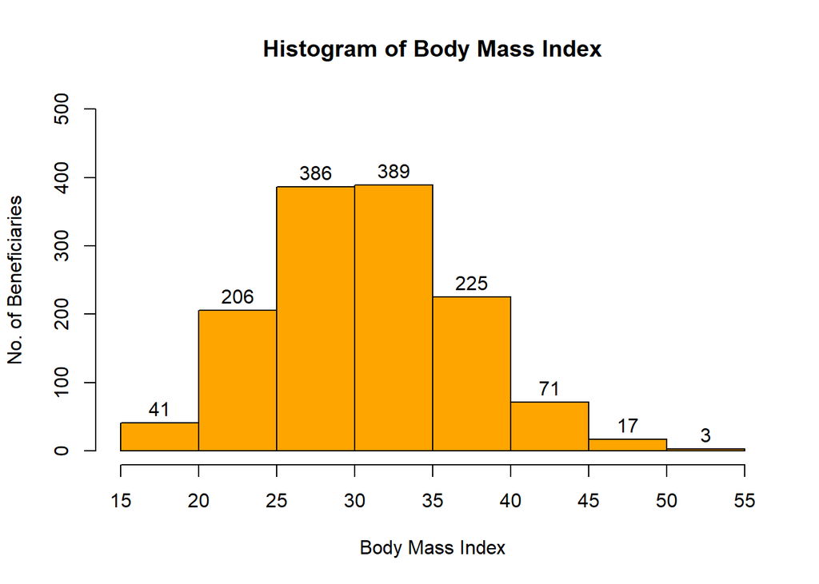

```r
h.bmi <- hist(df$bmi,
            main = "Histogram of Body Mass Index",
            labels = TRUE,
            xlab = "Body Mass Index",
            ylab = "No. of Beneficiaries",
            col = "orange",
            xlim = c(15, 55),
            ylim = c(0, 500),
            xaxp = c(15, 55, 8))
```

```r
bmi.group <- cut(df$bmi, breaks = h.bmi$breaks, include.lowest = TRUE, dig.lab = 5)
bmi_freq <- table(bmi.group)
kable(bmi_freq, caption = "Frequency Distribution by Body Mass Index")
```

Frequency Distribution by Body Mass Index

| bmi.group | Freq |
| --- | --- |
| [15,20] | 41 |
| (20,25] | 206 |
| (25,30] | 386 |
| (30,35] | 389 |
| (35,40] | 225 |
| (40,45] | 71 |
| (45,50] | 17 |
| (50,55] | 3 |

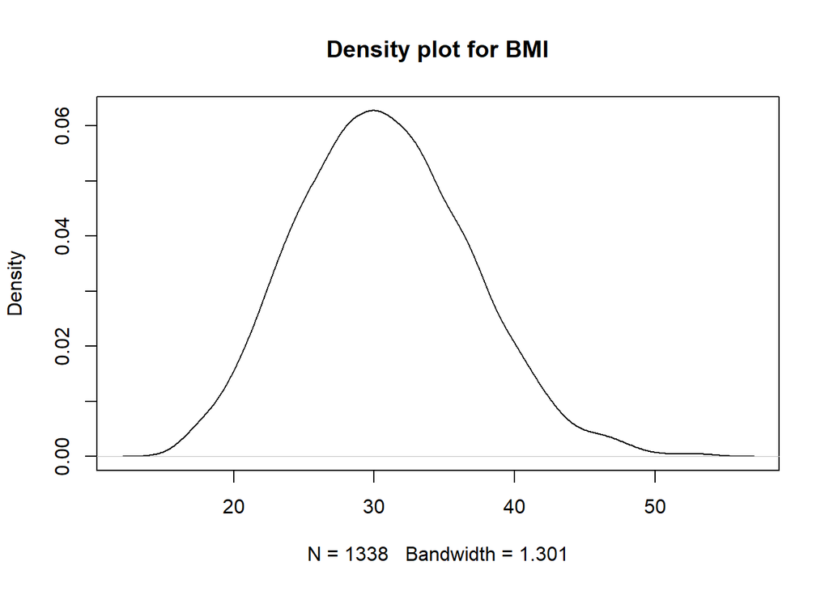

```r
plot(density(df$bmi), main="Density plot for BMI")
```

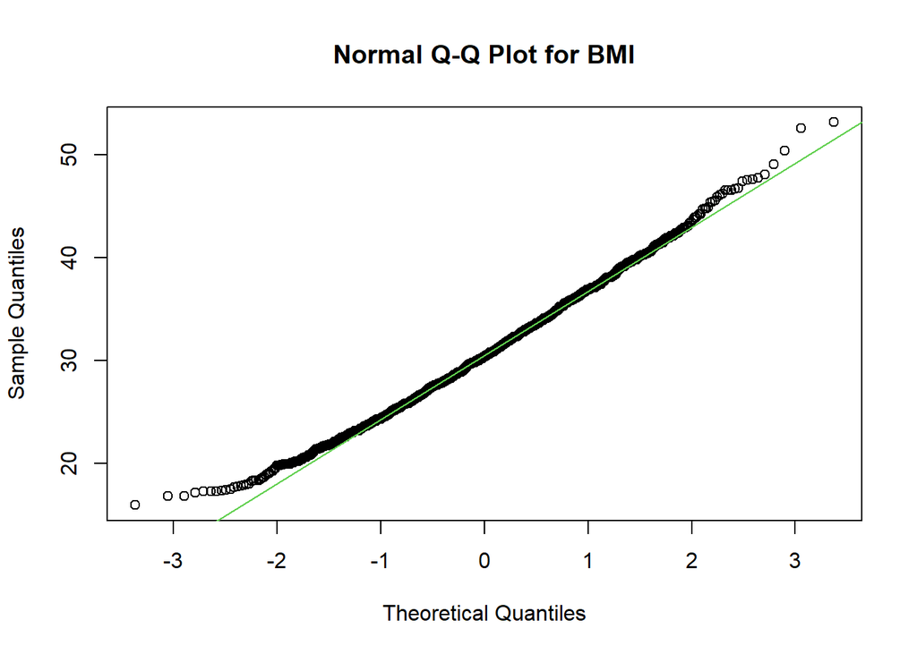

```r
qqnorm(df$bmi,
       main="Normal Q-Q Plot for BMI")
qqline(df$bmi, col=3)
```

FOR BMI: From the histogram, we see that the Body Mass Index (BMI) of primary beneficiaries is relatively normal, with majority of primary beneficiaries having a BMI of between 20 and 45. There are 3 extreme points of BMI found between 50 and 55, which can be considered outliers. This corroborates with the QQ-plot which closely follows the diagonal line. As the sample size here is large, although extreme values deviate from the diagonal line, it is not statistically significant.

- children

```r
childFreq <- df %>%
  count(children)

kable(childFreq, caption = "Frequency of Beneficiaries by Children Covered by Health Insurance")
```

Frequency of Beneficiaries by Children Covered by Health Insurance

| children | n |
| --- | --- |
| 0 | 574 |
| 1 | 324 |
| 2 | 240 |
| 3 | 157 |
| 4 | 25 |
| 5 | 18 |

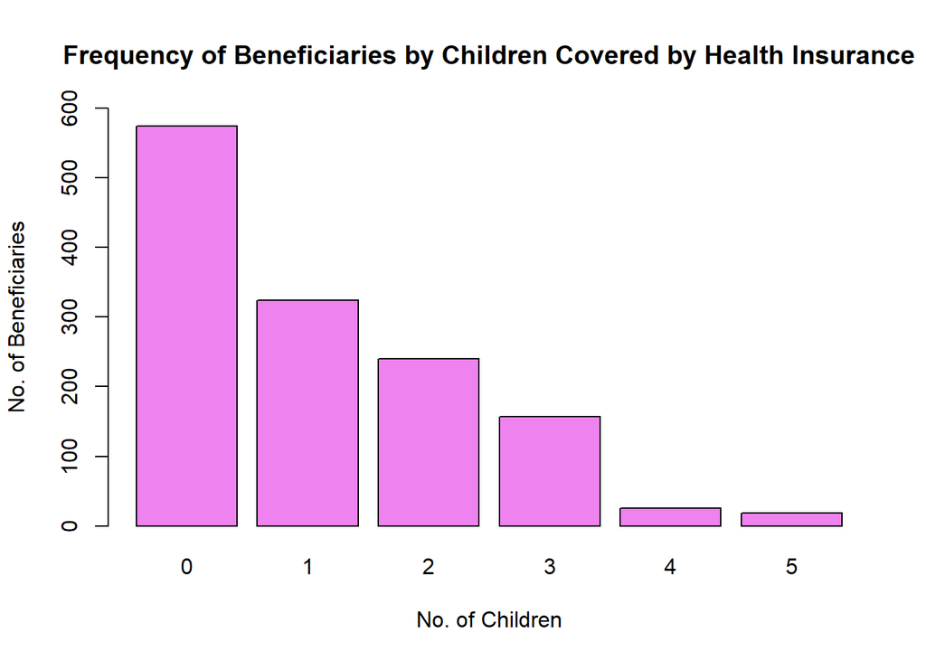

```r
childbar <- childFreq$n

barplot(childbar,
        names.arg = childFreq$children,
        col="violet",
        main="Frequency of Beneficiaries by Children Covered by Health Insurance",
        ylim=c(0,600),
        ylab="No. of Beneficiaries",
        xlab = "No. of Children")
```

Based on the bar chart, we see that the number of primary beneficiaries across the number of children which the primary beneficiary has is not balanced. We see that the number of primary beneficiaries is the highest among those with no children and lowest among those with 5 children. Beneficiaries with 0 to 3 children make up majority of primary beneficiaries.

- smoker

```r
smokeFreq <- df %>%
  count(smoker)

kable(smokeFreq, caption = "Frequency of Beneficiaries by Smoking Status")
```

Frequency of Beneficiaries by Smoking Status

| smoker | n |
| --- | --- |
| no | 1064 |
| yes | 274 |

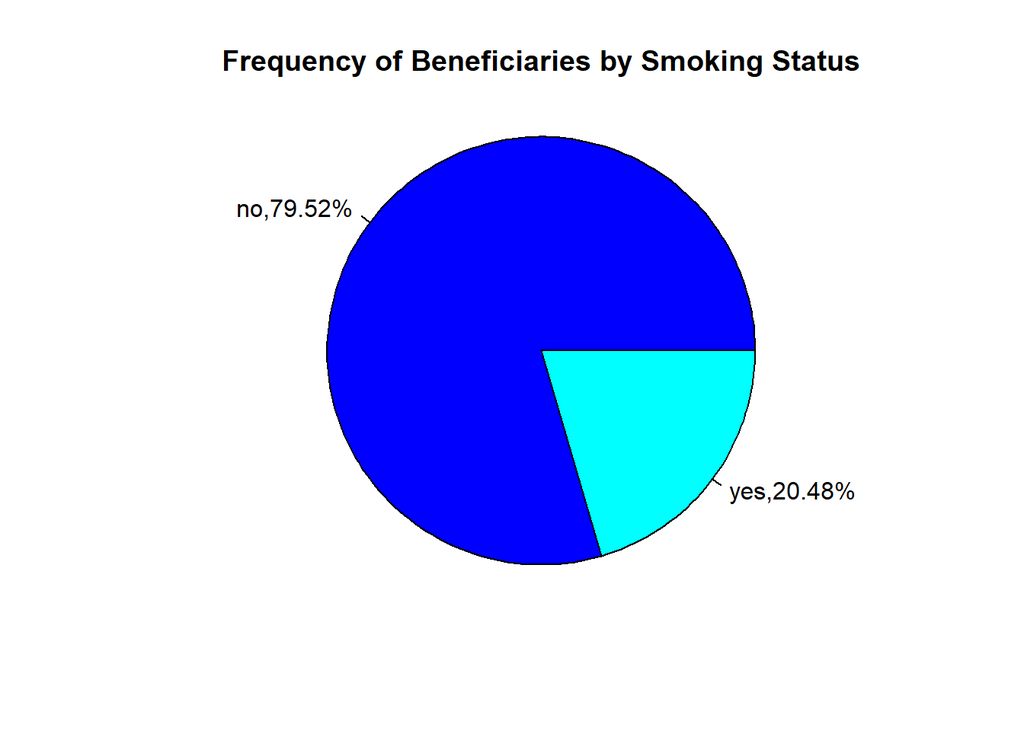

```r
slice.smoke <- smokeFreq$n
smoke.piepercent <- 100 * round(smokeFreq$n / sum(smokeFreq$n), 4)
label <- paste(smokeFreq$smoker, ",", sep = "", smoke.piepercent, "%")
pie(slice.smoke,
    labels = label,
    col = c("blue", "cyan"),
    radius = 1,
    main = "Frequency of Beneficiaries by Smoking Status")
```

From the pie chart, we see that majority (79.52%) of primary insurance beneficiaries do not smoke. However, we do not need to consider grouping smokers as a rare category since both are reasonably well represented and large enough for stable estimation, and we would likely lose interpretability if we grouped them differently.

- region

```r
regionFreq <- df %>%
  count(region)

kable(regionFreq, caption = "Frequency of Beneficiaries by Residential Region in the US")
```

Frequency of Beneficiaries by Residential Region in the US

| region | n |
| --- | --- |
| northeast | 324 |
| northwest | 325 |
| southeast | 364 |
| southwest | 325 |

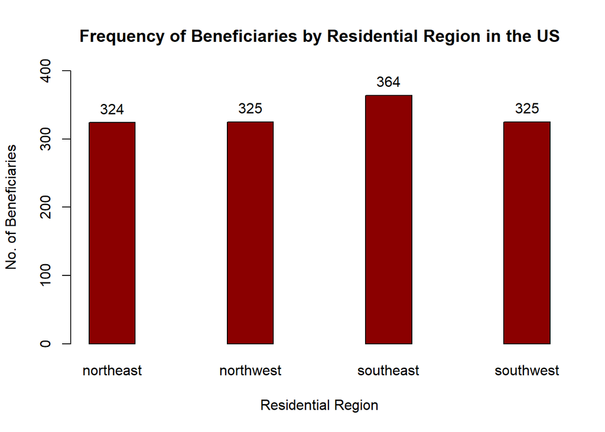

```r
regionbar <- regionFreq$n

region_bp <- barplot(regionbar,
                     names.arg = regionFreq$region,
                     col="darkred",
                     main="Frequency of Beneficiaries by Residential Region in the US",
                     ylim=c(0,400),
                     ylab="No. of Beneficiaries",
                     xlab = "Residential Region",
                     width = c(0.5, 0.5),
                     space = 2)

text(x=region_bp, y=regionbar, labels=round(regionbar,0), pos=3, xpd=NA)
```

Based on the bar chart, we see that that the frequency of beneficiaries across residential regions in the US is relatively balanced, with the number of beneficiaries per residential region being approximately 330.

## Association between Transformed Charges and age, bmi, children

We check whether assumptions of linearity, etc. are met before fitting the data into a multiple regression model.

- Transformed Charges against age

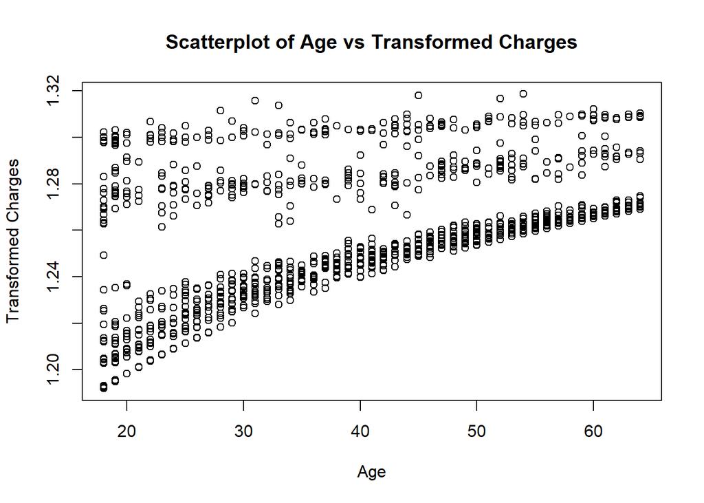

```r
plot(df$age,
     df$charges.t,
     main = "Scatterplot of Age vs Transformed Charges",
     xlab = "Age",
     ylab = "Transformed Charges",
     pch = 1)
```

- Transformed Charges against bmi

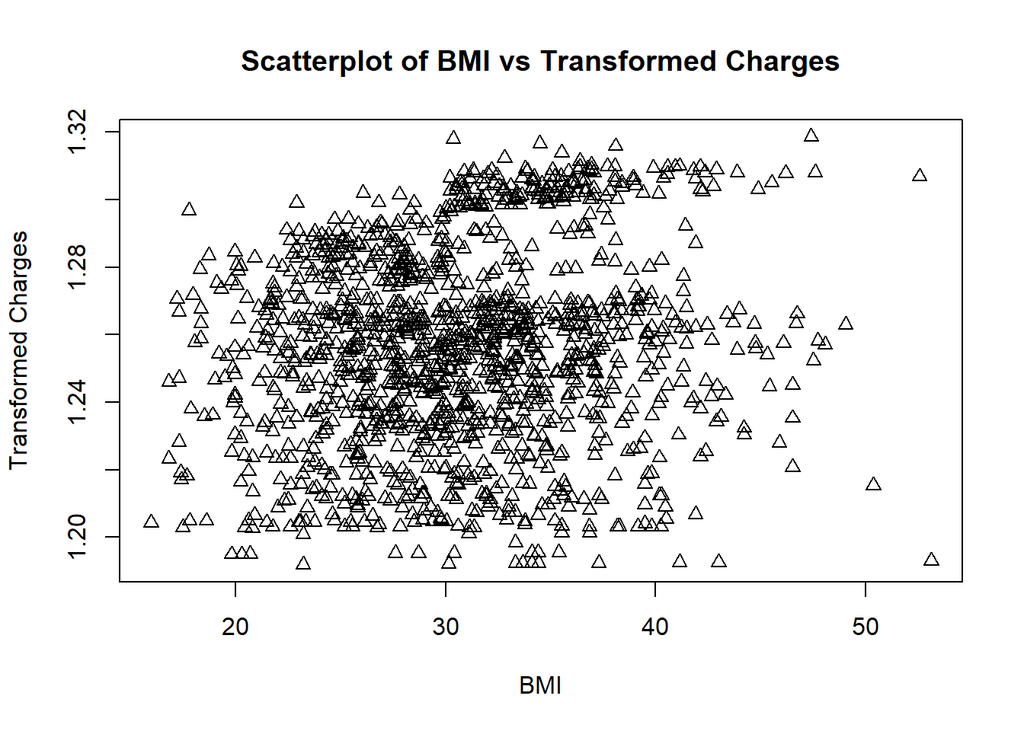

```r
plot(df$bmi,
     df$charges.t,
     main = "Scatterplot of BMI vs Transformed Charges",
     xlab = "BMI",
     ylab = "Transformed Charges",
     pch = 2)
```

- Transformed Charges against children

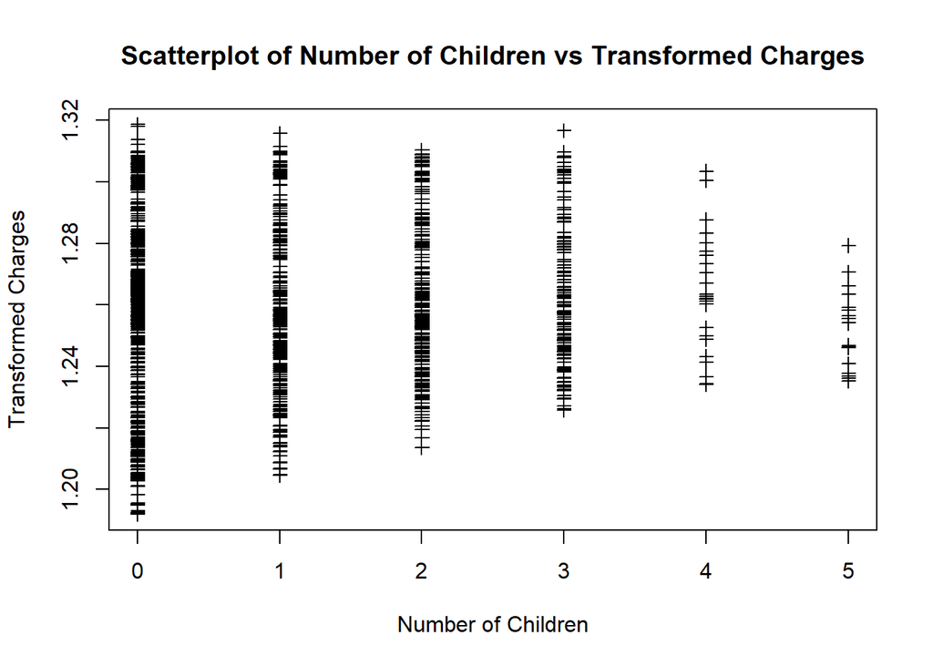

```r
plot(df$children,
     df$charges.t,
     main = "Scatterplot of Number of Children vs Transformed Charges",
     xlab = "Number of Children",
     ylab = "Transformed Charges",
     pch = 3)
```

The scatterplot shows that transformed charges remain relatively stable across different numbers of children, with a slight upward trend. No clear linear relationship is evident

- correlation matrix

```r
df.num <- df %>%
  select(charges.t, age, bmi, children)
corr.test(df.num)
```

```
## Call:corr.test(x = df.num)
## Correlation matrix
##           charges.t  age  bmi children
## charges.t      1.00 0.52 0.13     0.16
## age            0.52 1.00 0.11     0.04
## bmi            0.13 0.11 1.00     0.01
## children       0.16 0.04 0.01     1.00
## Sample Size
## [1] 1338
## Probability values (Entries above the diagonal are adjusted for multiple tests.)
##           charges.t  age  bmi children
## charges.t         0 0.00 0.00     0.00
## age               0 0.00 0.00     0.24
## bmi               0 0.00 0.00     0.64
## children          0 0.12 0.64     0.00
##
##  To see confidence intervals of the correlations, print with the short=FALSE option
```

We examined the variables BMI and children for potential transformations to improve linearity with the transformed response variable (charges.t). BMI was already approximately normally distributed, and no simple transformations (log, square root, polynomial, Tukey) produced a linear relationship with the transformed response. Similarly, children is a discrete count variable, and attempts at transformations did not produce a linear trend. Therefore, both variables were retained in their original form for modeling in order to preserve interpretability.

## Association between Transformed Charges and sex, smoker, region

- Transformed Charges against sex

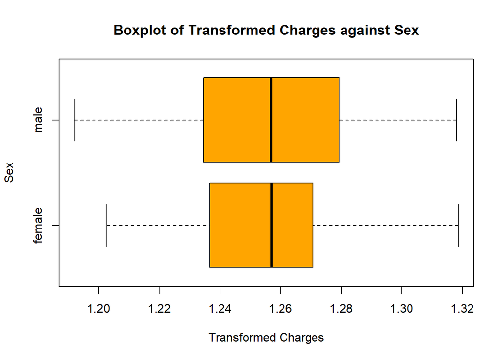

```r
bcharges.sex <- boxplot(df$charges.t~df$sex,
               horizontal = TRUE,
               xlab = "Transformed Charges",
               ylab = "Sex",
               main = "Boxplot of Transformed Charges against Sex",
               col = "orange")
```

- Transformed Charges against smoker

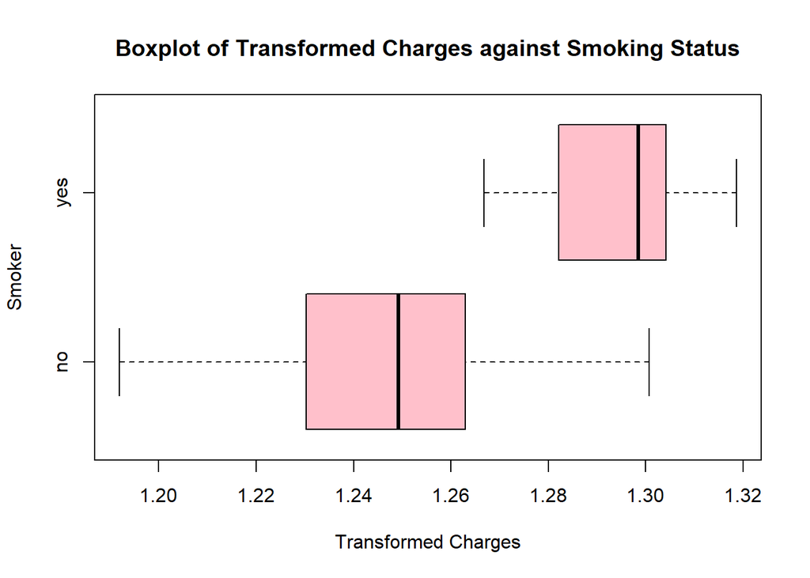

```r
bcharges.smoker <- boxplot(df$charges.t~df$smoker,
               horizontal = TRUE,
               xlab = "Transformed Charges",
               ylab = "Smoker",
               main = "Boxplot of Transformed Charges against Smoking Status",
               col = "pink")
```

```r
cor.test(df$charges.t, as.numeric(df$smoker == "yes"))
```

```
##
##  Pearson's product-moment correlation
##
## data:  df$charges.t and as.numeric(df$smoker == "yes")
## t = 33.111, df = 1336, p-value < 2.2e-16
## alternative hypothesis: true correlation is not equal to 0
## 95 percent confidence interval:
##  0.6408317 0.6997795
## sample estimates:
##       cor
## 0.6713661
```

- Transformed Charges against region

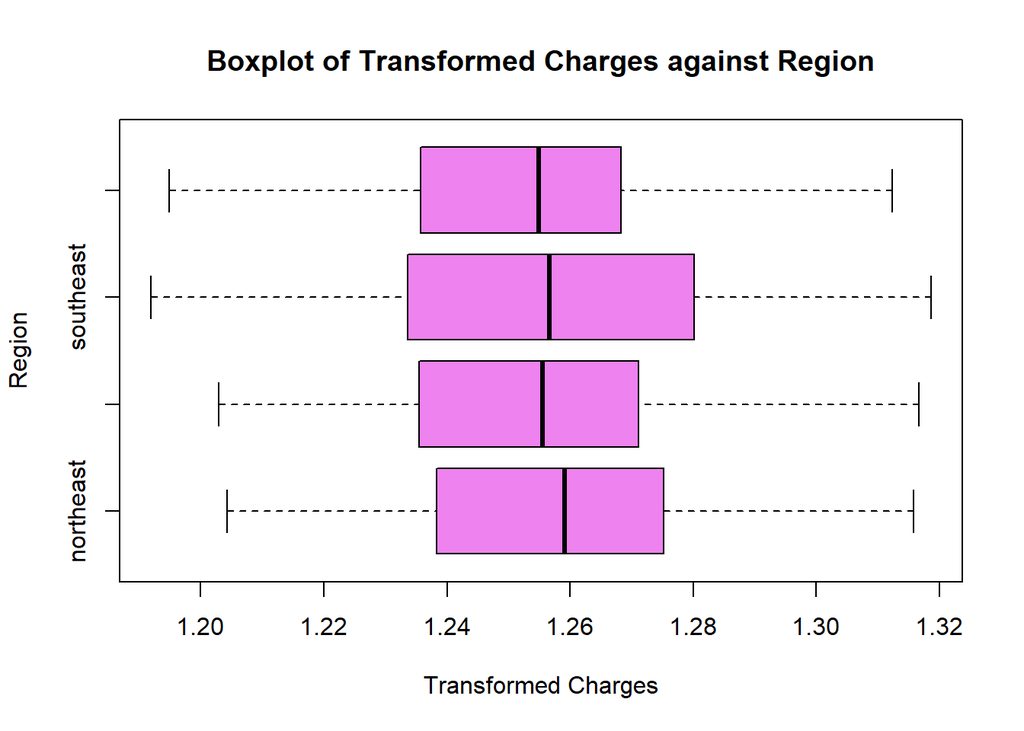

```r
bcharges.region <- boxplot(df$charges.t~df$region,
               horizontal = TRUE,
               xlab = "Transformed Charges",
               ylab = "Region",
               main = "Boxplot of Transformed Charges against Region",
               col = "violet")
```

For both categorical variables sex and region, the median and spread are similar in each group. Therefore, transformed charges is not associated with both variables. For categorical variable smoker, the median and spread are different in each group. Therefore, transformed charges is associated with smoker.

## Associations between Transformed Charges and Transformed Age

- Transformed Charges against Transformed Age

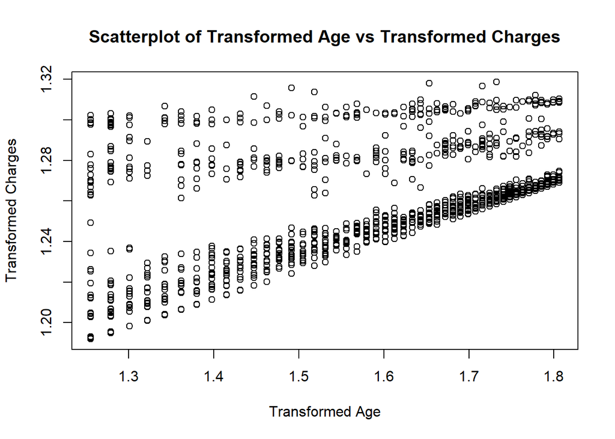

```r
df$age.t = log10(df$age)

plot(df$age.t,
     df$charges.t,
     main = "Scatterplot of Transformed Age vs Transformed Charges",
     xlab = "Transformed Age",
     ylab = "Transformed Charges",
     pch = 1)
```

```r
cor.test(df$charges.t, df$age.t)
```

```
##
##  Pearson's product-moment correlation
##
## data:  df$charges.t and df$age.t
## t = 22.791, df = 1336, p-value < 2.2e-16
## alternative hypothesis: true correlation is not equal to 0
## 95 percent confidence interval:
##  0.4893883 0.5666267
## sample estimates:
##       cor
## 0.5291026
```

## Interactions between explanatory variables

Association between variables is checked to identify potential interaction terms.

- age against sex

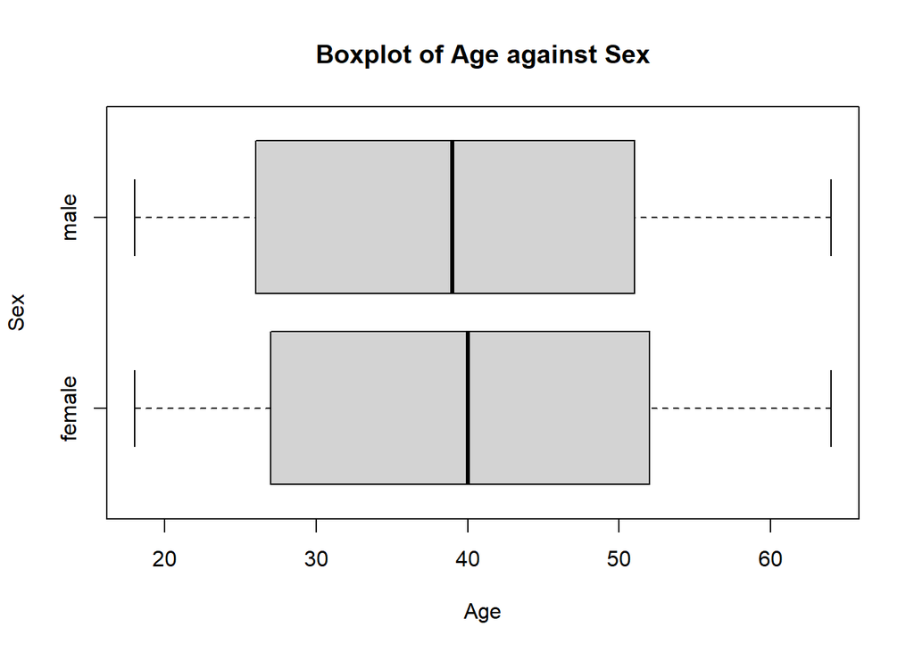

```r
bage.sex <- boxplot(df$age~df$sex,
               horizontal = TRUE,
               xlab = "Age",
               ylab = "Sex",
               main = "Boxplot of Age against Sex")
```

no association

- age against bmi

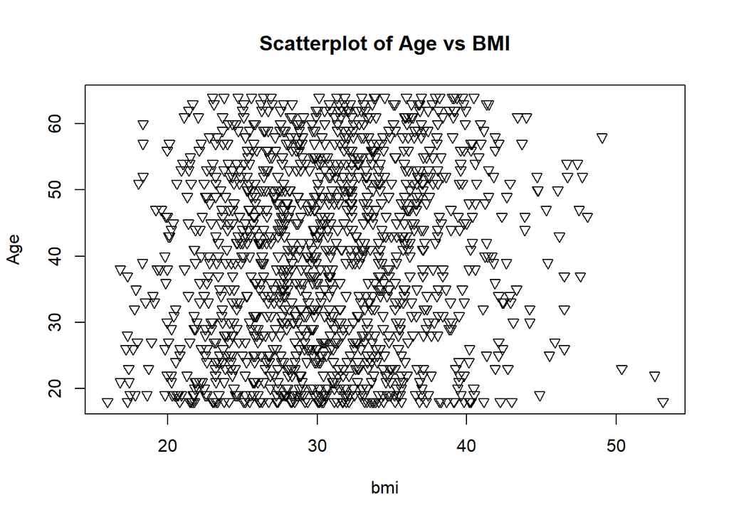

```r
plot(df$bmi,
     df$age,
     main = "Scatterplot of Age vs BMI",
     xlab = "bmi",
     ylab = "Age",
     pch = 6)
```

no association

- age against children

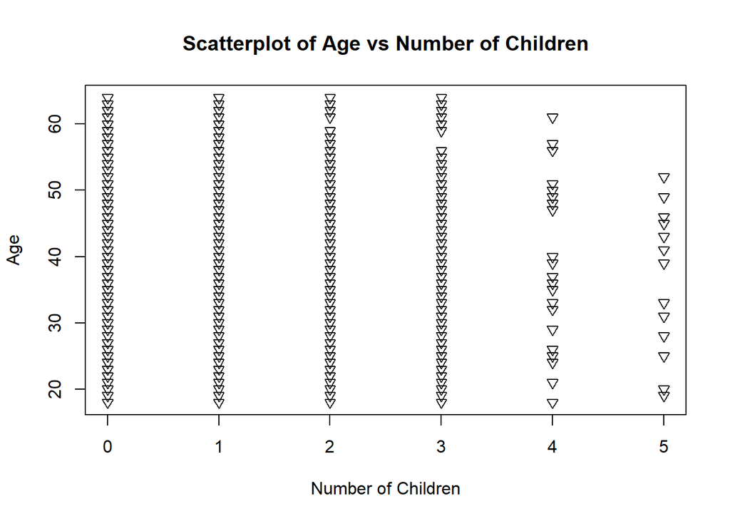

```r
plot(df$children,
     df$age,
     main = "Scatterplot of Age vs Number of Children",
     xlab = "Number of Children",
     ylab = "Age",
     pch = 6)
```

no association

- age against smoker

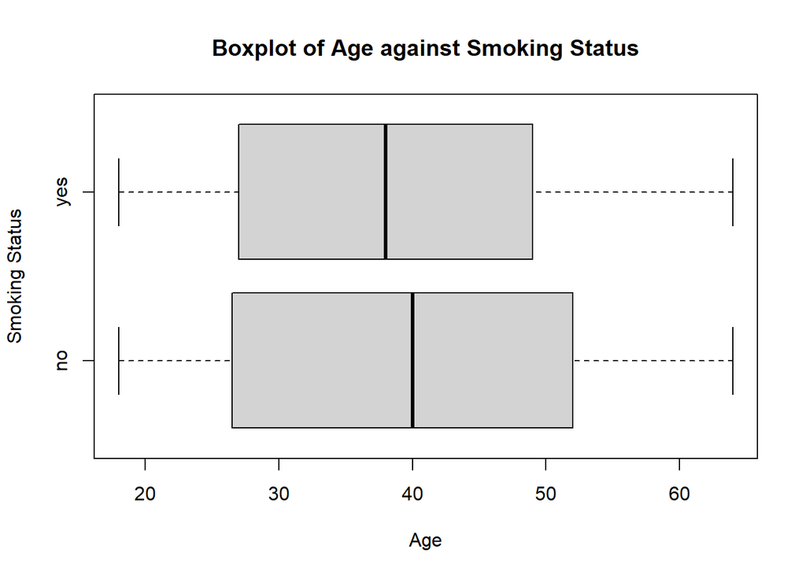

```r
bage.smoke <- boxplot(df$age~df$smoker,
               horizontal = TRUE,
               xlab = "Age",
               ylab = "Smoking Status",
               main = "Boxplot of Age against Smoking Status")
```

some association

- age against region

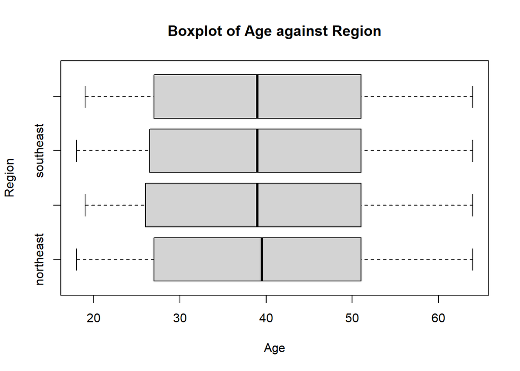

```r
bage.region <- boxplot(df$age~df$region,
               horizontal = TRUE,
               xlab = "Age",
               ylab = "Region",
               main = "Boxplot of Age against Region")
```

no association

- bmi against sex

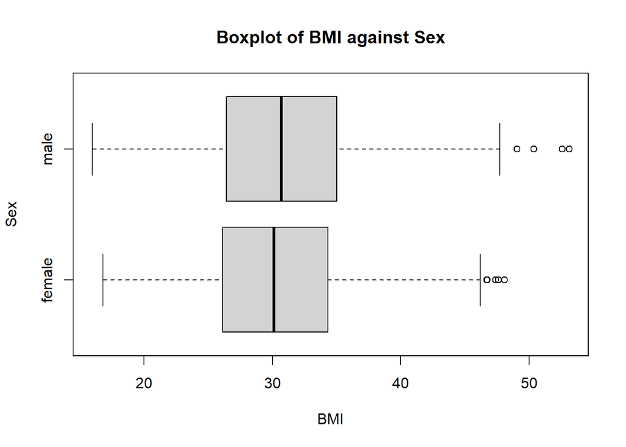

```r
bbmi.sex <- boxplot(df$bmi~df$sex,
               horizontal = TRUE,
               xlab = "BMI",
               ylab = "Sex",
               main = "Boxplot of BMI against Sex")
```

no association